# Live Session Unit 01 Assignment

Audrene Tiakor

February 15, 2019

*This assignment is to familarize onesself with R as a calculator.

# Question 1: Basic Math (20 pts)

### a. The log of a positive number

```r
log(4)
```

```
## [1] 1.386294
```

### b. What is the default base for the log function? Calculate the log of your previous number with a different base.

```r
log(4, base=4)
```

```
## [1] 1
```

### c. The log of a negative number. (explain the answer)

```r
log(-3)
```

```
## [1] NaN
```

### d. The squareroot of a positive number.

```r
sqrt(7)
```

```
## [1] 2.645751
```

# Question 2: Random Number Generation (15 pts)

### a. Create a vector of 15 standard normal random variables. Calculate its mean and SD:

```r
x <-rnorm(15, 0, 1)
x
```

```
##  [1] -0.40543301 -2.72051920 -1.22073937 -0.61156678  1.79111126
##  [6]  0.06803315 -0.81563720 -1.49535601 -0.58055563  0.84967473
## [11] -1.21635365  0.87973431  2.04315048  0.40961554 -0.77721424
```

```r
mean(x)
```

```
## [1] -0.2534704
```

```r
sd(x)
```

```
## [1] 1.277244
```

### b. Change the mean to 10 and the SD to 2. Recalculate the vector of 15 random variables. Find the mean and SD.

```r
x <-rnorm(15, 10, 2)
x
```

```
##  [1] 11.430051  8.983281 10.229332 11.282820  8.754950  9.014334 14.314235
##  [8]  8.713820 12.637346  9.101987 11.684726  9.225926 11.730969 11.721286
## [15] 10.018256
```

```r
mean(x)
```

```
## [1] 10.58955
```

```r
sd(x)
```

```
## [1] 1.679942
```

### c. Why are the means and SD not exactly the same as the means and SD’s specified in the function?

*Since the vector we created ‘x’ is of random variables, as the variables change, so does the mean and sd.

# Question 3: Vector Operations (40 pts)

### a. Create a vector of weights for 6 individuals in kg which are 60, 72, 57, 90, 95, 72

```r
w<-c(60, 72, 57, 90, 95, 72)
w
```

```
## [1] 60 72 57 90 95 72
```

```r
h<-c(60, 72, 57, 90, 95, 72)
h
```

```
## [1] 60 72 57 90 95 72
```

### c. create a data frame using the vectors w and h

```r
people<-data.frame(w,h)
people
```

```
##    w  h
## 1 60 60
## 2 72 72
## 3 57 57
## 4 90 90
## 5 95 95
## 6 72 72
```

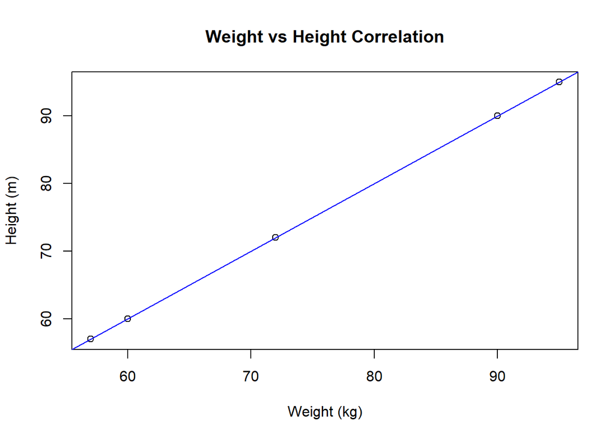

```r
 plot(w, h, main = "Weight vs Height Correlation", xlab = "Weight (kg)", ylab = "Height (m)", frame = TRUE)
abline(lm(h ~ w, data = people), col="blue")
```

```r
 options(scipen = 999, digits = 4)
 bmi <-function(w,h){
 w/(h^2)
   }
people$bmi = bmi(people$w,people$h)
print(people$bmi)
```

```
## [1] 0.01667 0.01389 0.01754 0.01111 0.01053 0.01389
```

### f. Calculate the mean for weight

```r
 people$mean_of_weight = mean(w)
 people
```

```
##    w  h     bmi mean_of_weight
## 1 60 60 0.01667          74.33
## 2 72 72 0.01389          74.33
## 3 57 57 0.01754          74.33
## 4 90 90 0.01111          74.33
## 5 95 95 0.01053          74.33
## 6 72 72 0.01389          74.33
```

```r
 people$diff =(people$w)
 print(people)
```

```
##    w  h     bmi mean_of_weight diff
## 1 60 60 0.01667          74.33   60
## 2 72 72 0.01389          74.33   72
## 3 57 57 0.01754          74.33   57
## 4 90 90 0.01111          74.33   90
## 5 95 95 0.01053          74.33   95
## 6 72 72 0.01389          74.33   72
```

```r
  sd_top<- function(w){
    mean(w) - w

 }
people$diff = sd_top(people$w)
print(people)
```

```
##    w  h     bmi mean_of_weight    diff
## 1 60 60 0.01667          74.33  14.333
## 2 72 72 0.01389          74.33   2.333
## 3 57 57 0.01754          74.33  17.333
## 4 90 90 0.01111          74.33 -15.667
## 5 95 95 0.01053          74.33 -20.667
## 6 72 72 0.01389          74.33   2.333
```

### f. Sum the result

```r
  sum(people$diff)
```

```
## [1] -0.00000000000002842
```

# Question 4: My Data Science Profile

```r
setwd("C:\\Users\\Audrene\\Desktop\\Doing Data Science\\HW_1")
Audrene <- read.table(file = "profile.csv",header = T,sep = ",")
Audrene
```

```
##             Categories Ranking
## 1 Computer Programming       2
## 2                 Math       4
## 3           Statistics       4
## 4     Machine Learning       1
## 5     Domain Expertise       1
## 6        Communication       3
## 7   Presentatin Skills       3
## 8   Data Visualization       2
```

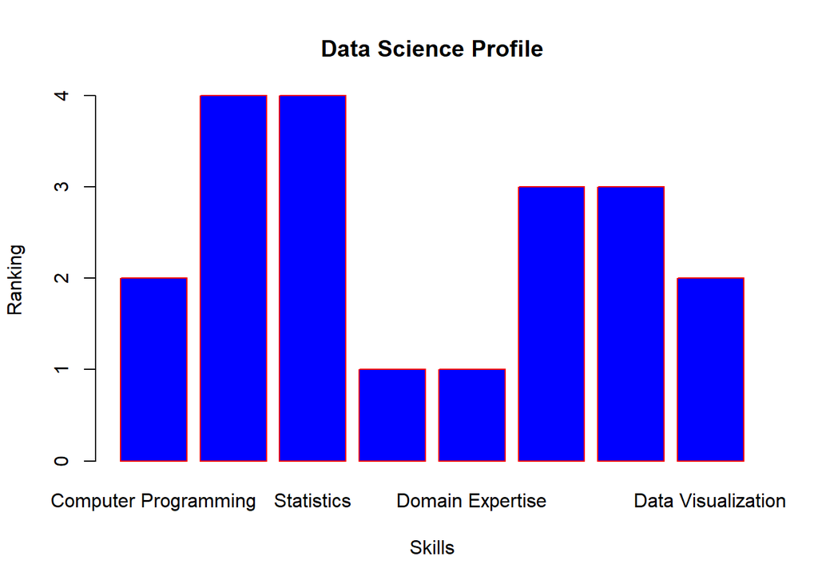

```r
barplot(Audrene$Ranking,names.arg=Audrene$Categories,xlab="Skills",ylab="Ranking",col="blue", main="Data Science Profile",border="red")
```